[figure not shown]

# Region level

### **England and Wales**

**Cautions and court sentences given to children (per 1,000) of general 10-17 population, from 1st of April 2021 to 31st March 2022.**

<sup>Source: Bespoke analysis of the Youth Justice Application Framework (YJAF). Population is based on the [2021 mid-year population estimates (ONS)](https://www.ons.gov.uk/peoplepopulationandcommunity/populationandmigration/populationestimates/datasets/populationestimatesforukenglandandwalesscotlandandnorthernireland) for 10-17 years old.</sup>

Note: Click on any region displays the actual value

[interactive chart not shown]

### **Table**

| Region | Number of Children | Population | Rate per 1,000 |
| --- | --- | --- | --- |
| East Midlands | 1521 | 448876 | 3.4 |
| Eastern | 2164 | 596032 | 3.6 |
| London | 4025 | 845463 | 4.8 |
| North East | 993 | 239483 | 4.1 |
| North West | 2265 | 691509 | 3.3 |
| South East | 3002 | 892087 | 3.4 |
| South West | 1661 | 502472 | 3.3 |
| Wales | 1030 | 286353 | 3.6 |
| West Midlands | 2225 | 576856 | 3.9 |
| Yorkshire | 2109 | 521605 | 4 |

### **Distribution**

<sup>A boxplot shows the distribution of numerical data and skewness through displaying the data quartiles (or percentiles). The box shows the interquartile range (data between the lower quartile Q1 and upper quartile Q3) with the black line indicating the median and the orange line the mean. Lines extend from each box to capture the range of the remaining data, with dots placed past the line edges to indicate outliers.</sup>

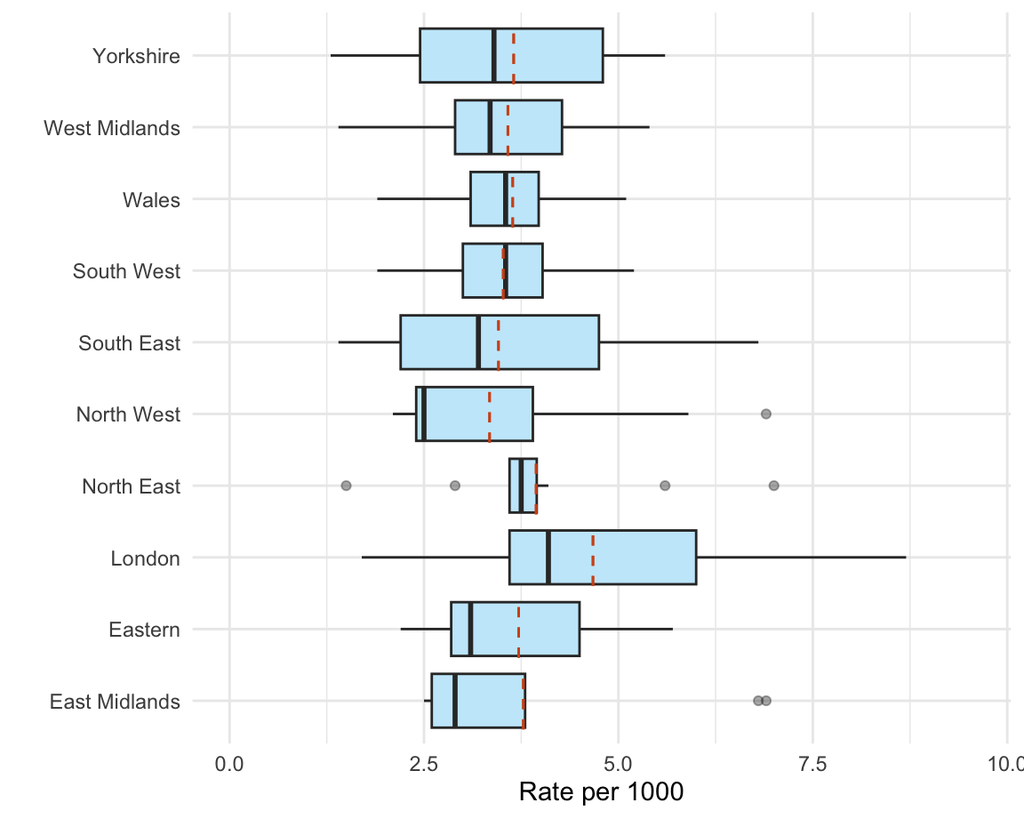

# YOT level

### **England and Wales**

**Cautions and court sentences given to children (per 1,000) of general 10-17 population, from 1st of April 2021 to 31st March 2022.**

<sup>Source: Bespoke analysis of the Youth Justice Application Framework (YJAF). Population is based on the [2021 mid-year population estimates (ONS)](https://www.ons.gov.uk/peoplepopulationandcommunity/populationandmigration/populationestimates/datasets/populationestimatesforukenglandandwalesscotlandandnorthernireland) for 10-17 years old.</sup>

Note: Click on any region displays the actual value

[interactive chart not shown]

### **Table**

| Region | Youth Justice Service | Number of Children | Population | Rate per 1,000 |
| --- | --- | --- | --- | --- |
| East Midlands | Derby | 179 | 26428 | 6.8 |
| East Midlands | Derbyshire | 197 | 70845 | 2.8 |
| East Midlands | Leicester City | 134 | 35417 | 3.8 |
| East Midlands | Leicestershire | 177 | 69517 | 2.5 |
| East Midlands | Lincolnshire | 190 | 65655 | 2.9 |
| East Midlands | Northamptonshire | 243 | 76141 | 3.2 |
| East Midlands | Nottingham | 201 | 29002 | 6.9 |
| East Midlands | Nottinghamshire | 200 | 75871 | 2.6 |
| Eastern | Bedfordshire | 138 | 45532 | 3 |
| Eastern | Cambridgeshire | 150 | 60903 | 2.5 |

[output cut: 144 more lines]